# TP — Séries temporelles batterie et identification d'un modèle électrique avec JAX

# 8. Identifiabilité et sensibilité à l'initialisation

Le modèle double shooting est maintenant fixé.

On répète exactement la même optimisation avec plusieurs initialisations aléatoires afin d'étudier la sensibilité du problème inverse.

On compare :

$$ SOC_0^{(1)},\quad SOC_0^{(2)},\quad C_{\max},\quad \tau_0,\quad R_i,\quad R_0(SOC,T),\quad R^2. $$

Une bonne qualité de prédiction de la tension ne garantit pas nécessairement que les mêmes paramètres physiques soient retrouvés.

On répète maintenant l'identification avec plusieurs initialisations.

La question n'est pas seulement :

> Est-ce que la tension est bien prédite ?

mais aussi :

> Est-ce que les mêmes paramètres physiques sont retrouvés ?

Deux ensembles de paramètres peuvent parfois donner des tensions très proches.

C'est un problème d'**identifiabilité pratique**.

```python
def train_double(seed,n_epochs=500):
    print(f"\n===== Initialisation {seed+1}/{N_IDENT_RUNS} =====")

    model=ECM2Shoot(jax.random.PRNGKey(seed))
    opt_state=optimizer_ms.init(eqx.filter(model,eqx.is_array))

    for epoch in range(n_epochs):
        model,opt_state,value=train_step_2shoot(model,opt_state)

        if epoch%50==0 or epoch==n_epochs-1:
            print(
                f"Epoch {epoch:4d} | "
                f"Loss = {float(value):.6f}"
            )

    SOC01=jax.nn.sigmoid(model.raw_soc01)
    SOC02=jax.nn.sigmoid(model.raw_soc02)
    CMAX=jnp.exp(model.log_Cmax)
    TAU0=jnp.exp(model.log_tau0)
    R=jnp.exp(model.log_R)

    return model,value,SOC01,SOC02,CMAX,TAU0,R
```

```python
results=[]
models_ident=[]

N_EPOCHS_IDENT = 250

for seed in range(N_IDENT_RUNS):

    model_seed,value,SOC01,SOC02,CMAX,TAU0,R=train_double(
        seed,
        n_epochs=N_EPOCHS_IDENT
    )

    U1,_,_=simulate_window(
        model_seed,model_seed.raw_soc01,
        I_1,T_1,dt_soc_1,dt_rc_1,gap_1
    )

    U2,_,_=simulate_window(
        model_seed,model_seed.raw_soc02,
        I_2,T_2,dt_soc_2,dt_rc_2,gap_2
    )

    U_seed=jnp.concatenate([U1,U2])

    R2_VOLTAGE=float(
        r2_score(U_id,U_seed)
    )

    models_ident.append(model_seed)

    results.append({
        "Run":seed+1,
        "Loss":float(value),
        "R2 tension":R2_VOLTAGE,
        "SOC01":float(SOC01),
        "SOC02":float(SOC02),
        "Cmax [Ah]":float(CMAX),
        "tau0 [s]":float(TAU0),
        "R1 [Ohm]":float(R[0]),
        "R2 [Ohm]":float(R[1]),
        "R3 [Ohm]":float(R[2]),
        "R4 [Ohm]":float(R[3])
    })

results=pd.DataFrame(results)
results
```

```
===== Initialisation 1/5 =====
Epoch    0 | Loss = 127.519591
Epoch   50 | Loss = 7.721956
Epoch  100 | Loss = 1.007246
Epoch  150 | Loss = 0.780636
Epoch  200 | Loss = 0.783576
Epoch  249 | Loss = 0.779227

===== Initialisation 2/5 =====
Epoch    0 | Loss = 153.179418
Epoch   50 | Loss = 7.835069
Epoch  100 | Loss = 1.113780
Epoch  150 | Loss = 0.818269
Epoch  200 | Loss = 0.769491
Epoch  249 | Loss = 0.763993

===== Initialisation 3/5 =====
Epoch    0 | Loss = 279.168816
Epoch   50 | Loss = 8.330444
Epoch  100 | Loss = 1.360040
Epoch  150 | Loss = 1.013302
Epoch  200 | Loss = 0.826924
Epoch  249 | Loss = 0.790168

===== Initialisation 4/5 =====
Epoch    0 | Loss = 165.311994
Epoch   50 | Loss = 7.906409
Epoch  100 | Loss = 1.069792
Epoch  150 | Loss = 0.776076
Epoch  200 | Loss = 0.751175
Epoch  249 | Loss = 0.766807

===== Initialisation 5/5 =====
Epoch    0 | Loss = 107.220332
Epoch   50 | Loss = 7.418437
Epoch  100 | Loss = 0.892525
Epoch  150 | Loss = 0.747907
Epoch  200 | Loss = 0.751110
Epoch  249 | Loss = 0.751933
```

|  | Run | Loss | R2 tension | SOC01 | SOC02 | Cmax [Ah] | tau0 [s] | R1 [Ohm] | R2 [Ohm] | R3 [Ohm] | R4 [Ohm] |
| --- | --- | --- | --- | --- | --- | --- | --- | --- | --- | --- | --- |
| 0 | 1 | 0.779227 | 0.999711 | 0.580411 | 0.773332 | 256.235363 | 6.587248 | 0.013240 | 0.017859 | 0.025311 | 0.032281 |
| 1 | 2 | 0.763993 | 0.999716 | 0.580148 | 0.773455 | 255.762995 | 6.269812 | 0.013393 | 0.016446 | 0.026973 | 0.033937 |
| 2 | 3 | 0.790168 | 0.999704 | 0.579926 | 0.773149 | 255.996681 | 6.697245 | 0.012315 | 0.013999 | 0.023104 | 0.042234 |
| 3 | 4 | 0.766807 | 0.999709 | 0.580392 | 0.773403 | 255.421497 | 6.523072 | 0.013283 | 0.016727 | 0.026699 | 0.032496 |
| 4 | 5 | 0.751933 | 0.999721 | 0.579747 | 0.773398 | 256.163259 | 7.525696 | 0.013011 | 0.018473 | 0.028050 | 0.029910 |

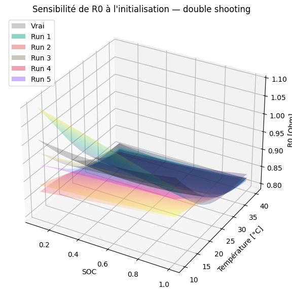

```python
from matplotlib.patches import Patch

fig=plt.figure(figsize=(10,7))
ax=fig.add_subplot(111,projection="3d")

SOC_mesh,T_mesh,_=make_r0_grid(models_ident[0])
R0_true=R0_true_function(SOC_mesh,T_mesh)

# R0 vrai
ax.plot_surface(
    np.array(SOC_mesh),
    np.array(T_mesh),
    np.array(R0_true),
    color="black",
    alpha=0.20,
    linewidth=0
)

CMAPS=[
    "viridis",
    "plasma",
    "cividis",
    "magma",
    "cool"
]

legend_handles=[
    Patch(
        facecolor="black",
        alpha=0.20,
        label="Vrai"
    )
]

# R0 issus des différentes initialisations
for i,model_i in enumerate(models_ident):

    _,_,R0_i=make_r0_grid(model_i)

    cmap_name=CMAPS[i%len(CMAPS)]
    cmap=plt.colormaps[cmap_name]

    ax.plot_surface(
        np.array(SOC_mesh),
        np.array(T_mesh),
        np.array(R0_i),
        cmap=cmap_name,
        alpha=0.30,
        linewidth=0
    )

    legend_handles.append(
        Patch(
            facecolor=cmap(0.6),
            alpha=0.5,
            label=f"Run {i+1}"
        )
    )

ax.set_xlabel("SOC")
ax.set_ylabel("Température [°C]")
ax.set_zlabel("R0 [Ohm]")
ax.set_title(
    "Sensibilité de R0 à l'initialisation — double shooting"
)

ax.legend(handles=legend_handles,loc="upper left")

plt.show()
```

On répète exactement la même identification avec différentes initialisations aléatoires. Si plusieurs runs donnent une loss similaire mais des paramètres ou des fonctions $R_0$ différents, cela met en évidence un problème potentiel d'identifiabilité.

# Note

Refaire le TP avec DOWNSAMPLE_STEP=1, remarques ?

# Conclusion

Ce TP montre qu'à partir de séries temporelles relativement simples — courant, tension et température — il est possible de reconstruire une partie de l'état interne d'une batterie et d'identifier les paramètres d'un modèle dynamique.

L'exercice met surtout en évidence plusieurs difficultés importantes :

- une bonne prédiction de la tension ne garantit pas que tous les paramètres identifiés soient physiquement corrects ;
- l'estimation du SOC par intégration peut dériver sur des fenêtres longues ;
- le choix de la fenêtre d'identification et des états initiaux influence fortement les résultats ;
- le multiple shooting permet de limiter une partie de ce drift en recalant certains états ;
- plusieurs jeux de paramètres peuvent parfois expliquer presque aussi bien les mêmes mesures : c'est la question de l'identifiabilité.

Le problème ne consiste donc pas uniquement à obtenir un faible écart sur la tension, mais aussi à vérifier que les états reconstruits et les paramètres estimés restent cohérents et robustes.

Enfin, ce type d'approche illustre l'intérêt des méthodes de **Scientific Machine Learning** : combiner un modèle physique dynamique, des paramètres classiques, un réseau de neurones et l'autodifférentiation dans un même problème d'optimisation.